# Capital social declarado das empresas brasileiras

Distribuição, concentração e qualidade do registro em 141.332 cadastros do CNPJ CE302 — Elementos de Programação para Estatística · UFPR · 2026.2

Ana Sofia

Breno Dias

Camila Ogawa

Henrique Kotelok

Maria Oliveira

26 de novembro de 2026

# 1 Introdução

## 1.1 O capital social como objeto de registro

Toda sociedade empresária constituída no Brasil declara, no ato de registro, o valor do seu capital social: a soma que os sócios formalmente comprometem com a pessoa jurídica, em dinheiro ou em bens suscetíveis de avaliação econômica, nos termos do art. 997 do Código Civil (BRASIL, 2002). Esse valor é averbado no Cadastro Nacional da Pessoa Jurídica (CNPJ), mantido pela Secretaria Especial da Receita Federal, e integra o conjunto de dados abertos que o órgão publica periodicamente (RECEITA FEDERAL DO BRASIL, 2026).

A natureza desse campo merece atenção antes de qualquer análise, porque determina o que ele pode e o que não pode informar. O capital social não é receita, não é faturamento e não é patrimônio corrente. É uma declaração de intenção feita em um momento específico, normalmente o da abertura da empresa, e que só é atualizada quando a sociedade promove alteração contratual com esse objetivo. Uma empresa aberta em 2004 com capital de cem mil reais que nunca formalizou aumento permanece, no cadastro, com cem mil reais, ainda que hoje movimente valores de outra ordem. O inverso também ocorre: nada impede que uma sociedade declare capital elevado e jamais o integralize.

Essa distância entre o valor declarado e a realidade econômica costuma ser tratada como defeito do dado; neste trabalho ela é tratada como parte do objeto. O que o cadastro registra é um comportamento declaratório, e comportamentos declaratórios deixam marcas estatísticas reconhecíveis: concentração em valores redondos, picos em quantias de referência e caudas formadas por poucos declarantes de magnitude muito superior à do restante. Localizar essas marcas e medir a sua extensão é boa parte do que se segue.

## 1.2 Por que a distribuição do capital interessa

Grandezas econômicas raramente se distribuem de forma simétrica. Renda, riqueza, tamanho de firma, volume de vendas e valor de ativos apresentam, com regularidade documentada há mais de um século, distribuições fortemente assimétricas à direita, frequentemente bem aproximadas pela lognormal no corpo e por uma lei de potência na cauda (AITCHISON; BROWN, 1957; LIMPERT; STAHEL; ABBT, 2001; PARETO, 1896). A consequência prática dessa regularidade é que os resumos estatísticos aprendidos para dados simétricos deixam de ser informativos: a média deixa de representar o caso típico, o desvio padrão deixa de delimitar uma faixa plausível, e o intervalo de dois desvios em torno da média pode incluir valores negativos que a variável não admite.

O capital social declarado oferece um caso quase didático desse problema, com um agravante que o torna mais interessante do que o habitual. Além da assimetria própria da variável, o cadastro contém valores que não descrevem nenhuma realidade econômica, como declarações de exatamente cem bilhões de reais repetidas em dezenas de cadastros distintos. Esses registros são poucos, mas participam da soma total com peso suficiente para distorcer qualquer estatística que dependa de agregados. Analisar essa base exige, portanto, decidir o que fazer com eles antes de calcular a primeira média, e a decisão não é neutra: ela muda o resultado por quase duas ordens de magnitude.

## 1.3 Problema e objetivos

O problema que organiza este relatório pode ser enunciado em uma pergunta: o que a distribuição do capital social declarado revela sobre o universo de empresas registradas no Brasil, e quanto dessa distribuição é propriedade da economia e quanto é propriedade do processo de declaração?

Dessa pergunta decorrem cinco objetivos específicos. O primeiro é caracterizar a forma da distribuição do capital social, verificando se a aproximação lognormal usual se sustenta e em que faixa ela falha. O segundo é quantificar o grau de concentração do capital declarado por meio da curva de Lorenz e do índice de Gini, acompanhados de medida de incerteza. O terceiro é avaliar se o porte declarado pela empresa e a sua forma jurídica discriminam o capital, e com que magnitude, distinguindo a existência de diferença da sua relevância prática. O quarto é descrever o comportamento da cauda superior da distribuição, estimando o expoente que a governa. O quinto, e que atravessa todos os anteriores, é diagnosticar a qualidade do registro: identificar arredondamento, ancoragem em valores de referência e declarações implausíveis, e medir o efeito de cada um desses fenômenos sobre as estatísticas calculadas.

## 1.4 Organização do relatório

A Seção 2 descreve a origem dos dados, a sua estrutura, o pré-processamento aplicado e as técnicas estatísticas empregadas, com atenção às razões de cada escolha. A Seção 3 apresenta e discute os resultados, começando pela forma da distribuição e pelos padrões de arredondamento, passando pelos cortes categóricos disponíveis, pela cauda superior e pela concentração, e encerrando no diagnóstico de qualidade e na quantificação do seu efeito. A Seção 4 retoma os achados, registra as limitações do delineamento e aponta desdobramentos. O apêndice documenta o ambiente computacional e o aplicativo interativo desenvolvido como segunda parte do trabalho.

Todos os números citados no texto são calculados em tempo de compilação a partir do arquivo de dados e inseridos por código embutido, de modo que o relatório não pode afirmar um valor diferente do que as suas próprias figuras mostram.

# 2 Materiais e Métodos

## 2.1 Origem dos dados e recorte

Os dados provêm do projeto TidyTuesday, iniciativa semanal de divulgação de conjuntos de dados para prática de análise em R, na edição de 27 de janeiro de 2026 (R4DS ONLINE LEARNING COMMUNITY, 2026). O conjunto foi extraído do CNPJ e distribuído em quatro arquivos CSV: um com os cadastros das empresas e três com as tabelas de domínio que traduzem os códigos de natureza jurídica, de qualificação do responsável e de porte.

O recorte aplicado na origem é determinante para a leitura dos resultados e precisa ser declarado desde já. A base não contém todas as empresas do CNPJ: contém apenas as que declararam capital social superior a cento e cinquenta mil reais. Trata-se, portanto, de uma amostra truncada à esquerda em um ponto conhecido. O menor valor observado é de R$ 150.000,09, e esse truncamento tem consequências que reaparecem em três momentos da análise. A primeira é que a base exclui a maioria numérica das empresas brasileiras, concentrada em microempreendedores individuais e sociedades de capital simbólico. A segunda é que o índice de Gini calculado aqui não mede a desigualdade do universo empresarial, e sim a desigualdade interna do grupo que já se situa acima do corte. A terceira, discutida na Seção 3.2, é que o truncamento invalida a aplicação direta da lei de Benford, porque remove parte dos valores iniciados pelo dígito um.

Não há no conjunto qualquer variável temporal, geográfica ou de atividade econômica. Não existe data de abertura, unidade federativa, município ou código CNAE. Essa ausência exclui do escopo três famílias inteiras de análise que seriam naturais em dados empresariais: séries temporais, comparações regionais e cortes setoriais. A delimitação do trabalho não é, portanto, uma escolha de conveniência, e sim o conjunto do que estas seis colunas sustentam.

## 2.2 Estrutura das variáveis

A Tabela 2.1 descreve as variáveis utilizadas, já com os nomes resultantes do pré-processamento descrito na seção seguinte.

Tabela 2.1: Variáveis utilizadas na análise, após o pré-processamento. As três últimas colunas da base original guardam códigos numéricos que foram substituídos pelos rótulos das tabelas de domínio.

| Variável | Tipo | Descrição |
| --- | --- | --- |
| company_id | inteiro | Identificador do cadastro na base de origem |
| company_name | texto | Razão social da empresa |
| capital_stock | numérica contínua | Capital social declarado, em reais |
| company_size | categórica ordinal | Porte declarado: microempresa, pequena empresa ou demais |
| legal_nature | categórica nominal | Forma jurídica da sociedade (14 categorias observadas) |
| owner_qualification | categórica nominal | Qualificação do responsável legal (12 categorias observadas) |
| log10_capital | numérica derivada | Logaritmo de base 10 do capital social |
| capital_suspeito | lógica derivada | Indicador de valor implausível (capital maior ou igual a R$ 10 bi) |

A base reúne 141.332 cadastros. Há uma única variável quantitativa, o capital social, e três categóricas, das quais apenas o porte tem ordem natural. Essa composição condiciona todo o repertório metodológico: sem segunda variável contínua não há correlação, regressão linear simples nem diagrama de dispersão entre quantitativas, e as relações investigadas são necessariamente do tipo quantitativa contra categórica ou categórica contra categórica.

## 2.3 Ambiente computacional e reprodutibilidade

A análise foi conduzida em R 4.6.1 (R CORE TEAM, 2026). Os gráficos foram produzidos com ggplot2 (WICKHAM, 2016) e o relatório foi escrito em R Markdown, compilado com knitr e com as extensões de referência cruzada do pacote bookdown (XIE, 2016; XIE; ALLAIRE; GROLEMUND, 2018). O aplicativo interativo que compõe a segunda parte do trabalho foi construído com shiny (CHANG et al., 2026).

Nenhuma biblioteca externa de estatística foi utilizada para os procedimentos centrais. O índice de Gini, o coeficiente de assimetria, o tamanho de efeito do teste de Kruskal-Wallis, o V de Cramér e o estimador de Hill foram implementados a partir das suas definições, e o código está visível ao longo do texto. A opção se justifica no contexto da disciplina: a implementação explícita deixa a fórmula verificável, elimina divergências de convenção entre pacotes, como a correção amostral do coeficiente de assimetria, e evita acrescentar dependências que precisariam ser instaladas para reproduzir o documento.

## 2.4 Pré-processamento

O tratamento dos dados foi isolado em três scripts executados em sequência, separação que atende a uma exigência prática: a importação precisa ser reproduzível sem depender da análise, e a análise precisa ser recompilável sem baixar vinte megabytes de CSV a cada tentativa.

O primeiro script baixa os quatro arquivos de origem apenas se eles ainda não estiverem presentes no diretório local, de modo que execuções repetidas não geram tráfego desnecessário. O segundo faz a importação propriamente dita e o terceiro produz um arquivo de diagnóstico com as contagens e os extremos de cada variável, usado na conferência manual dos resultados.

Quatro decisões tomadas na importação merecem registro.

A primeira é a verificação de contrato. Antes de qualquer transformação, o script confere por meio de asserções que as colunas esperadas existem, que o capital social é numérico e positivo, e que as três colunas de código encontram correspondência integral nas tabelas de domínio; uma asserção que falha interrompe a importação com mensagem explícita. A alternativa seria descobrir o problema adiante, na forma de um gráfico vazio ou de uma categoria chamada `NA`, com o erro já distante da sua causa.

A segunda é a tradução dos códigos. As três colunas categóricas chegam como inteiros e são substituídas pelos rótulos das respectivas tabelas de domínio. Os rótulos permanecem em inglês, como na origem; a tradução para o português dos três níveis de porte é aplicada apenas na apresentação, por uma função de rotulagem compartilhada entre o relatório e o aplicativo.

A terceira é a ordenação do porte. Microempresa, pequena empresa e demais empresas formam uma escala, e declarar a variável como fator ordenado garante que ela apareça nessa ordem em todo gráfico e em toda tabela, sem que cada chamada precise repetir a sequência. Fatores não ordenados são dispostos alfabeticamente, o que colocaria “demais empresas” antes de “microempresa” e produziria eixos cuja leitura contraria o conteúdo.

A quarta é a marcação, e não a exclusão, dos valores implausíveis. A coluna lógica `capital_suspeito` identifica os cadastros com capital declarado igual ou superior a dez bilhões de reais. A escolha de marcar preserva a possibilidade de medir o efeito desses registros, que é um dos resultados do trabalho, e deixa a decisão de incluí-los ou não em cada análise visível no código em vez de escondida em uma etapa anterior. O aplicativo interativo expõe essa marcação como uma caixa de seleção, de modo que o leitor pode reproduzir o efeito por conta própria.

Foram derivadas, por fim, duas colunas de conveniência: o logaritmo de base dez do capital, que é a escala em que a variável se lê, e o capital expresso em milhões, usado em eixos.

## 2.5 Técnicas empregadas

### 2.5.1 Descrição de distribuições assimétricas

A descrição da variável quantitativa privilegia estatísticas de posição resistentes a valores extremos. Relatam-se a mediana, os quartis e os percentis de 1, 10, 90 e 99, acompanhados da amplitude interquartílica. A média e o desvio padrão são informados, porém com a finalidade explícita de exibir a sua inadequação neste caso, exercício na linha da análise exploratória proposta por Tukey (1977).

O coeficiente de assimetria é calculado como o terceiro momento padronizado, $g_1 = m_3 / m_2^{3/2}$, com os momentos centrais estimados pela divisão por $n$. Toda a visualização da variável é feita em escala logarítmica de base dez, decisão que não é estética: em escala linear, com máximo na casa dos bilhões e mediana na casa das centenas de milhares, mais de noventa por cento das observações se acumulariam na primeira barra de um histograma e a figura não informaria nada. A adequação da transformação é avaliada por gráfico quantil-quantil do logaritmo contra a distribuição normal, procedimento usual quando se suspeita de comportamento lognormal (LIMPERT; STAHEL; ABBT, 2001).

### 2.5.2 Comparação entre grupos

A comparação do capital entre os níveis de porte e entre as formas jurídicas usa o teste de Kruskal-Wallis (KRUSKAL; WALLIS, 1952), extensão não paramétrica da análise de variância baseada em postos (CONOVER; IMAN, 1981). A escolha decorre da forma da distribuição: a análise de variância clássica pressupõe normalidade dos resíduos e homogeneidade de variâncias, e nenhuma das duas se sustenta aqui, nem mesmo após a transformação logarítmica, como o gráfico quantil-quantil deixa ver.

O valor-p do teste, isoladamente, é desprovido de interesse neste conjunto. Com mais de cento e quarenta mil observações, qualquer diferença entre grupos, ainda que trivial, produz rejeição da hipótese nula. Esse comportamento é bem documentado e constitui um dos argumentos centrais contra o uso do valor-p como medida de relevância em grandes amostras (HUNTINGTON-KLEIN, 2017). Relata-se portanto, junto ao teste, o tamanho de efeito

$$\varepsilon^2 = \frac{H - k + 1}{n - k},$$

em que $H$ é a estatística do teste, $k$ o número de grupos e $n$ o número de observações. A quantidade se interpreta como a proporção da variabilidade dos postos atribuível ao agrupamento, e permite dizer se a diferença detectada é grande ou pequena, pergunta que o valor-p não responde. Adotam-se como referência os patamares convencionais de 0,01, 0,06 e 0,14 para efeitos pequeno, médio e grande (COHEN, 1988).

### 2.5.3 Associação entre variáveis categóricas

A associação entre porte e forma jurídica é avaliada pelo teste de independência de qui-quadrado sobre a tabela de contingência, com o coeficiente V de Cramér como medida de intensidade (CRAMÉR, 1946):

$$V = \sqrt{\frac{\chi^2}{n\,(\min(r,c) - 1)}},$$

em que $r$ e $c$ são o número de linhas e de colunas da tabela. O coeficiente varia entre zero e um e, ao contrário da estatística de qui-quadrado, não cresce com o tamanho da amostra, o que o torna comparável entre tabelas de dimensões diferentes. A motivação para esse exame é substantiva e não decorativa: se porte e forma jurídica estiverem associados, a diferença de capital observada entre formas jurídicas pode ser, em parte, a diferença de porte entre elas, e a leitura causal ingênua fica interditada.

### 2.5.4 Medidas de concentração

A concentração do capital é descrita pela curva de Lorenz (LORENZ, 1905), que relaciona a proporção acumulada de empresas, ordenadas do menor para o maior capital, à proporção acumulada do capital total que elas detêm. O índice de Gini (GINI, 1921) resume a curva pela razão entre a área que a separa da diagonal de igualdade e a área total sob a diagonal. O cálculo adotado usa a forma baseada na covariância entre o valor e o seu posto:

$$G = \frac{2\sum_{i=1}^{n} i\,x_{(i)}}{n\sum_{i=1}^{n} x_{(i)}} - \frac{n+1}{n},$$

com $x_{(i)}$ denotando a $i$-ésima observação em ordem crescente. Essa forma é algebricamente equivalente à definição por áreas e dispensa integração numérica, o que importa em uma base deste tamanho (COWELL, 2011).

A incerteza do índice é estimada por reamostragem com reposição (EFRON, 1979), com mil repetições, reportando-se o intervalo percentílico de 95 por cento. O procedimento é necessário porque o índice de Gini é uma estatística de forma complicada, sem expressão fechada simples para o erro padrão, e porque a sua sensibilidade à cauda superior torna razoável duvidar da sua estabilidade antes de verificá-la.

### 2.5.5 Diagnóstico de qualidade do registro

Três procedimentos compõem o diagnóstico. O primeiro é a contagem de valores repetidos, que localiza as quantias de referência em que as declarações se acumulam. O segundo é a análise do grau de arredondamento, medido pelo número de zeros à direita de cada valor inteiro declarado, que quantifica em que medida as declarações são números redondos em vez de montantes calculados. O terceiro é a distribuição do primeiro dígito significativo, confrontada com a lei de Benford (BENFORD, 1938), ferramenta corrente em auditoria para detectar dados que não se formaram por processo natural de medida (NIGRINI, 2012).

A aplicação do terceiro procedimento exige cautela que a literatura aplicada nem sempre observa, e que aqui é explicitada: a lei de Benford pressupõe dados que percorrem várias ordens de magnitude sem corte, e a base está truncada em cento e cinquenta mil reais. O truncamento remove parte dos valores iniciados por um, de modo que o desvio em relação à lei esperada tem ao menos duas causas distintas, e a análise só pode ser lida como descritiva.

### 2.5.6 Comportamento da cauda

A cauda superior é examinada por meio do gráfico da função de sobrevivência empírica em escala duplamente logarítmica, no qual uma lei de potência aparece como reta (NEWMAN, 2005). O expoente é estimado pelo estimador de Hill (HILL, 1975),

$$\hat{\alpha} = \left[\frac{1}{n_u}\sum_{x_i > u} \ln\frac{x_i}{u}\right]^{-1},$$

calculado para dois limiares $u$, a fim de verificar a estabilidade da estimativa. O interesse do procedimento é direto: um expoente estimado abaixo de um indica distribuição de média teórica infinita, situação em que a média amostral não converge e deixa de ser um resumo utilizável, o que fornece justificativa formal para a preferência pela mediana adotada em todo o relatório.

## 2.6 Limitações do delineamento

Quatro limitações acompanham a leitura dos resultados. A amostra é truncada à esquerda, de modo que nenhum resultado aqui descreve o universo das empresas brasileiras, e sim o subconjunto que declarou capital superior a cento e cinquenta mil reais. A variável é declaratória e não auditada: não informa faturamento, patrimônio ou atividade, e a sua desatualização é permitida pela própria norma que a institui. Não há dimensão temporal, o que impede qualquer afirmação sobre tendência, crescimento ou efeito de política. Não há, por fim, identificação de grupo econômico, de forma que empresas de um mesmo conglomerado aparecem como cadastros independentes e a concentração medida é concentração entre cadastros, não entre proprietários, o que a torna um limite inferior da concentração real de propriedade.

# 3 Resultados e Discussão

## 3.1 A forma da distribuição

A Tabela 3.1 apresenta as estatísticas descritivas do capital social no recorte de análise, composto por 141.070 empresas.

Tabela 3.1: Estatísticas descritivas do capital social declarado, excluídos os 262 valores implausíveis. O coeficiente de assimetria é adimensional.

| Estatística | Valor |
| --- | --- |
| Mínimo | R$ 150.000 |
| 1º percentil | R$ 160.000 |
| 1º decil | R$ 200.000 |
| 1º quartil | R$ 210.000 |
| Mediana | R$ 400.000 |
| Média | R$ 9.084.049 |
| 3º quartil | R$ 1.000.000 |
| 9º decil | R$ 3.790.000 |
| 99º percentil | R$ 156.748.912 |
| Máximo | R$ 9.888.717.805 |
| Amplitude interquartílica | R$ 790.000 |
| Desvio padrão | R$ 122.909.919 |
| Coeficiente de assimetria | 46,0 |

A leitura conjunta dessas estatísticas já estabelece o problema central da variável. A mediana é de R$ 400.000 e a média é de R$ 9.084.049, ou seja, a média supera a mediana em um fator de 22,7. Em uma distribuição simétrica as duas medidas coincidem; aqui, a média não é o valor típico nem está próxima dele. A sua posição corresponde ao percentil 94,4, de modo que 94,4 por cento das empresas declaram capital inferior ao valor que a média anuncia como central.

O desvio padrão, de R$ 122.909.919, é 307,3 vezes maior que a mediana. A faixa convencional de dois desvios em torno da média começa em R$ -236.735.789, valor negativo que a variável não admite por definição, o que torna a estatística inútil como descrição de dispersão. O coeficiente de assimetria, 46,0, confirma quantitativamente o que essas discrepâncias sugerem: a distribuição é fortemente assimétrica à direita, muito além do que se observa em dados que justificariam resumos baseados em momentos.

A Figura 3.1 mostra a distribuição em escala logarítmica.

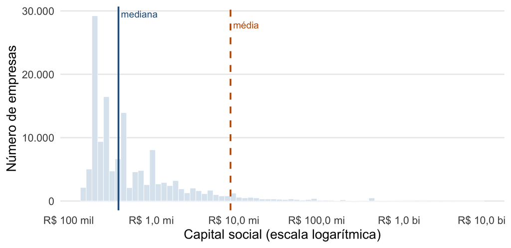

Figura 3.1: Distribuição do capital social declarado em escala logarítmica de base 10. A linha contínua marca a mediana e a tracejada a média; a distância horizontal entre elas é a assimetria da variável traduzida em imagem. Os picos isolados correspondem a valores de referência declarados repetidamente, examinados na Seção 3.2.

```r
med_log <- log10(mediana)
mea_log <- log10(media)

ggplot(validas, aes(x = log10_capital)) +
  geom_histogram(bins = 70, fill = CORES$claro, colour = "white",
                 linewidth = 0.2) +
  geom_vline(xintercept = med_log, colour = CORES$principal, linewidth = 0.8) +
  geom_vline(xintercept = mea_log, colour = CORES$destaque, linewidth = 0.8,
             linetype = "dashed") +
  annotate("text", x = med_log, y = Inf, label = " mediana", hjust = 0,
           vjust = 1.6, size = 3.3, colour = CORES$principal) +
  annotate("text", x = mea_log, y = Inf, label = " média", hjust = 0,
           vjust = 3.2, size = 3.3, colour = CORES$destaque) +
  scale_x_continuous(labels = rotulo_log10, n.breaks = 7) +
  scale_y_continuous(labels = function(v) numero_pt(v)) +
  labs(x = "Capital social (escala logarítmica)", y = "Número de empresas") +
  tema_app()
```

A adequação da aproximação lognormal é avaliada na Figura 3.2.

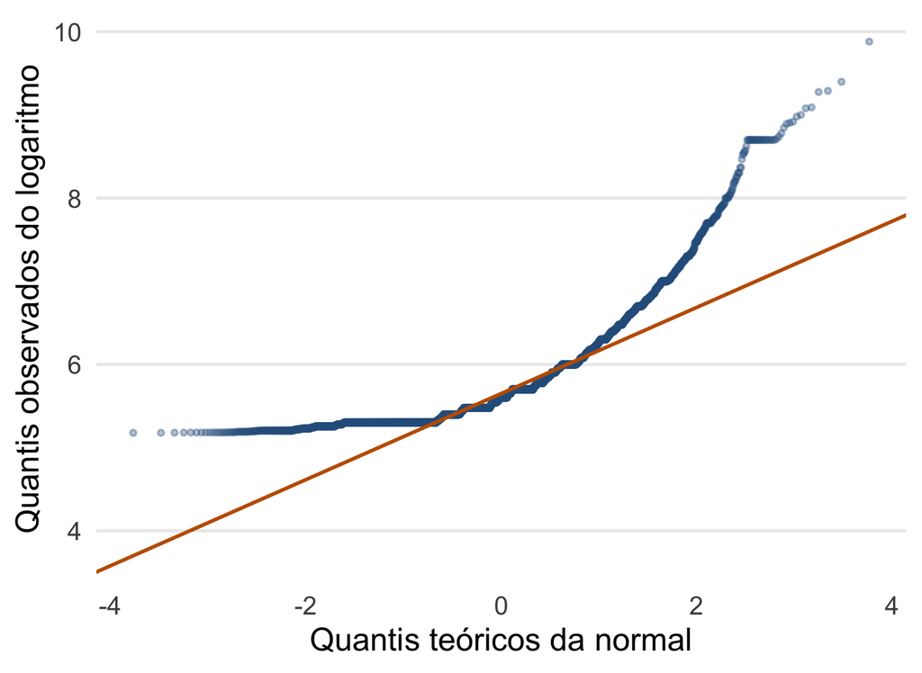

Figura 3.2: Gráfico quantil-quantil do logaritmo do capital social contra a distribuição normal. O alinhamento é satisfatório na região central e se rompe nas duas extremidades: à esquerda pelo truncamento da amostra, à direita pela cauda pesada.

```r
amostra <- sample(validas$log10_capital, 6000)

ggplot(data.frame(x = amostra), aes(sample = x)) +
  stat_qq(colour = CORES$principal, alpha = 0.35, size = 0.8) +
  stat_qq_line(colour = CORES$destaque, linewidth = 0.7) +
  labs(x = "Quantis teóricos da normal",
       y = "Quantis observados do logaritmo") +
  tema_app()
```

```r
lg <- validas$log10_capital
faixa_central <- lg >= quantile(lg, .05) & lg <= quantile(lg, .95)
assim_log      <- assimetria(lg)
assim_log_cen  <- assimetria(lg[faixa_central])
```

O alinhamento dos pontos à reta de referência é bom ao longo da faixa central e se deteriora nas duas pontas, por razões diferentes. À esquerda, o desvio é produzido pelo truncamento da amostra em cento e cinquenta mil reais, que elimina a parte inferior da distribuição e cria um limite inferior abrupto onde a normal preveria continuidade. À direita, o desvio tem origem na cauda pesada: os maiores valores observados são muito superiores ao que a distribuição normal atribuiria àqueles quantis, o que é precisamente o comportamento de uma lei de potência e será quantificado na Seção 3.6.

A transformação logarítmica reduz a assimetria de 46,0 para 2,08, e na faixa central, entre o 5º e o 95º percentis, o coeficiente cai a 1,08. O conjunto desses resultados sustenta uma conclusão qualificada: a lognormal descreve bem o corpo da distribuição, mas não as suas extremidades, e qualquer procedimento que dependa de normalidade do logaritmo em toda a faixa estaria mal fundamentado. É essa constatação que justifica, adiante, o recurso a métodos baseados em postos.

## 3.2 Arredondamento e ancoragem

A Figura 3.1 exibe picos que uma variável econômica contínua não produziria. A sua origem está no modo como as declarações são formadas: o capital social não é medido, e sim escolhido, e quem escolhe prefere números redondos.

```r
inteiros <- capital[capital == floor(capital)]
n_cent   <- length(capital) - length(inteiros)
txt      <- formatC(inteiros, format = "d")
zeros    <- nchar(txt) - nchar(sub("0+$", "", txt))

mult <- data.frame(
  `Grau de arredondamento` = c("Qualquer valor inteiro",
                               "Múltiplo de R$ 1.000",
                               "Múltiplo de R$ 10.000",
                               "Múltiplo de R$ 100.000",
                               "Múltiplo de R$ 1.000.000"),
  Empresas = c(length(inteiros),
               sum(inteiros %%  1e3 == 0),
               sum(inteiros %%  1e4 == 0),
               sum(inteiros %%  1e5 == 0),
               sum(inteiros %%  1e6 == 0)),
  check.names = FALSE, stringsAsFactors = FALSE
)
mult$`% dos inteiros` <- numero_pt(100 * mult$Empresas / length(inteiros), 1)
mult$Empresas <- numero_pt(mult$Empresas)

knitr::kable(mult, align = c("l", "r", "r"), caption = "Grau de arredondamento das declarações inteiras de capital social. Cada linha é um subconjunto da anterior.")
```

Tabela 3.2: Grau de arredondamento das declarações inteiras de capital social. Cada linha é um subconjunto da anterior.

| Grau de arredondamento | Empresas | % dos inteiros |
| --- | --- | --- |
| Qualquer valor inteiro | 138.333 | 100,0 |
| Múltiplo de R$ 1.000 | 122.136 | 88,3 |
| Múltiplo de R$ 10.000 | 112.068 | 81,0 |
| Múltiplo de R$ 100.000 | 82.891 | 59,9 |
| Múltiplo de R$ 1.000.000 | 13.354 | 9,7 |

O resultado é expressivo. Dos 138.333 valores inteiros declarados, 88,3 por cento são múltiplos de mil e 59,9 por cento são múltiplos de cem mil. Apenas 7,5 por cento das declarações inteiras terminam em dígito diferente de zero. Em uma variável que resultasse de cálculo contábil, como a soma do valor de bens integralizados, não haveria razão para essa regularidade.

Vale registrar o contraste oferecido pelo grupo minoritário: 2.737 cadastros, 1,9 por cento do total, declaram capital com centavos. São presumivelmente os casos em que o valor decorre de uma conta efetivamente realizada, e a sua raridade reforça a leitura de que a regra geral é a escolha de uma quantia de referência.

A Figura 3.3 identifica quais são essas quantias.

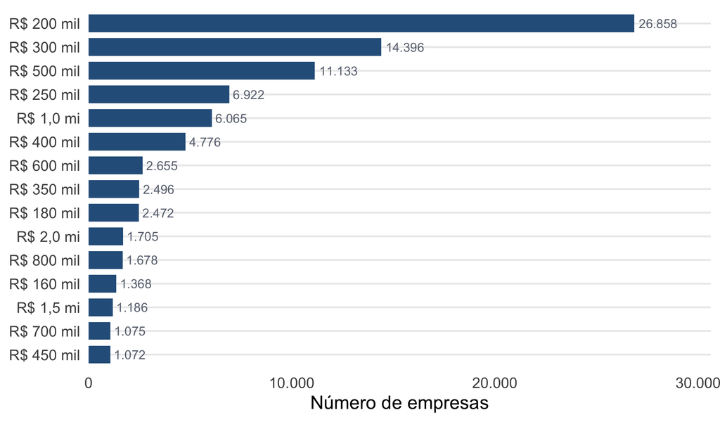

Figura 3.3: Os quinze valores de capital social mais frequentemente declarados e o número de empresas que declaram exatamente cada um deles. Juntos, respondem por mais de metade da base.

```r
cont <- sort(table(capital), decreasing = TRUE)
top  <- head(cont, 15)
df_top <- data.frame(
  valor = as.numeric(names(top)),
  n     = as.integer(top)
)
df_top$rotulo <- reais_curto(df_top$valor)

ggplot(df_top, aes(x = reorder(rotulo, n), y = n)) +
  geom_col(fill = CORES$principal, width = 0.75) +
  geom_text(aes(label = numero_pt(n)), hjust = -0.12, size = 3.1,
            colour = CORES$neutro) +
  coord_flip() +
  scale_y_continuous(labels = function(v) numero_pt(v),
                     expand = expansion(mult = c(0, 0.14))) +
  labs(x = NULL, y = "Número de empresas") +
  tema_app()
```

```r
n_distintos <- length(unique(capital))
share_top10 <- 100 * sum(head(cont, 10)) / length(capital)
share_top1  <- 100 * cont[1] / length(capital)
valor_top1  <- as.numeric(names(cont)[1])
```

Os 141.070 cadastros distribuem-se por apenas 22.378 valores distintos, e os dez valores mais comuns cobrem 56,3 por cento da base. O valor mais declarado é R$ 200.000, escolhido por 26.858 empresas, ou 19,0 por cento do total. Duzentos mil reais, trezentos mil, quinhentos mil e um milhão formam, juntos, um conjunto de quatro quantias que concentra parcela desproporcional das declarações, e todas são exatamente o tipo de número que uma pessoa escolhe quando precisa informar um valor plausível sem calculá-lo.

```r
primeiro <- as.integer(substr(formatC(capital, format = "f", digits = 0), 1, 1))
obs <- 100 * prop.table(table(factor(primeiro, levels = 1:9)))
esp <- 100 * log10(1 + 1 / (1:9))

ben <- data.frame(
  Dígito     = 1:9,
  Observado  = numero_pt(as.numeric(obs), 2),
  `Benford`  = numero_pt(esp, 2),
  Diferença  = numero_pt(as.numeric(obs) - esp, 2),
  check.names = FALSE
)
knitr::kable(ben, align = c("c", "r", "r", "r"), caption = "Distribuição percentual do primeiro dígito significativo do capital social declarado, comparada à proporção prevista pela lei de Benford. A comparação é descritiva: o truncamento da amostra em R$ 150 mil impede sua leitura como teste.")
```

Tabela 3.3: Distribuição percentual do primeiro dígito significativo do capital social declarado, comparada à proporção prevista pela lei de Benford. A comparação é descritiva: o truncamento da amostra em R$ 150 mil impede sua leitura como teste.

| Dígito | Observado | Benford | Diferença |
| --- | --- | --- | --- |
| 1 | 19,58 | 30,10 | -10,53 |
| 2 | 33,28 | 17,61 | 15,67 |
| 3 | 17,14 | 12,49 | 4,64 |
| 4 | 7,46 | 9,69 | -2,23 |
| 5 | 11,40 | 7,92 | 3,49 |
| 6 | 4,07 | 6,69 | -2,62 |
| 7 | 2,61 | 5,80 | -3,19 |
| 8 | 2,76 | 5,12 | -2,35 |
| 9 | 1,70 | 4,58 | -2,88 |

A Tabela 3.3 confronta a distribuição observada do primeiro dígito significativo com a proporção prevista pela lei de Benford. O afastamento é grande e tem sinal definido em ambos os extremos. O dígito dois aparece em 33,3 por cento das declarações, contra 17,6 por cento esperados, enquanto o dígito um aparece em 19,6 por cento contra os 30,1 por cento previstos.

As duas discrepâncias têm causas distintas, e separá-las importa. O excesso de dígito dois é efeito direto da ancoragem documentada na Figura 3.3: duzentos mil reais e dois milhões estão entre os valores mais declarados. A falta de dígito um, por outro lado, é artefato do truncamento, e não propriedade do comportamento declaratório. A base começa em cento e cinquenta mil reais, de modo que todas as declarações situadas entre cem e cento e cinquenta mil reais, que começariam por um, foram removidas na origem, e o mesmo ocorre nas faixas correspondentes de cada ordem de magnitude inferior. Um relatório que apresentasse esta tabela como evidência de irregularidade estaria atribuindo ao declarante um efeito produzido pelo recorte da amostra. É por essa razão que a comparação é aqui apresentada como descrição, e não como teste.

## 3.3 Porte declarado e capital social

O porte é a única variável categórica com ordem natural, o que permite verificar se a classificação declarada guarda relação com o valor declarado.

Tabela 3.4: Distribuição do capital social por porte declarado, com o índice de Gini calculado dentro de cada grupo.

| Porte | Empresas | % | 1º quartil | Mediana | 3º quartil | Gini interno |
| --- | --- | --- | --- | --- | --- | --- |
| Microempresa | 66.193 | 46,9 | R$ 200.000 | R$ 300.000 | R$ 500.000 | 0,924 |
| Pequena empresa | 32.402 | 23,0 | R$ 200.000 | R$ 350.000 | R$ 700.000 | 0,944 |
| Demais empresas | 42.475 | 30,1 | R$ 460.000 | R$ 1.032.966 | R$ 3.527.470 | 0,924 |

```r
kw <- kruskal.test(capital ~ porte)
k  <- length(levels(porte))
eps2 <- (unname(kw$statistic) - k + 1) / (length(capital) - k)
```

A Tabela 3.4 traz um resultado que contraria a expectativa razoável. Microempresa e pequena empresa, que são categorias legalmente definidas por faixas distintas de receita bruta anual (BRASIL, 2006; SEBRAE, 2024), apresentam medianas de capital R$ 300.000 e R$ 350.000, praticamente indistinguíveis. A categoria residual, que reúne as empresas não enquadradas em nenhuma das duas, separa-se das demais com mediana de R$ 1.032.966.

O teste de Kruskal-Wallis rejeita a hipótese de igualdade das distribuições, com $H = 27.607,5$ e $p < 2{,}2 \times 10^{-16}$. Esse resultado, por si, nada informa. Em uma amostra deste tamanho a rejeição era esperada antes de qualquer cálculo, e tratá-la como achado seria confundir detectabilidade com relevância. O tamanho de efeito é $\varepsilon^2 = 0,196$, valor que situa a diferença no patamar classificado como grande pelas referências convencionais (COHEN, 1988) e que, ao mesmo tempo, deixa 80,4 por cento da variabilidade dos postos sem explicação pelo porte.

A Figura 3.4 mostra as distribuições completas.

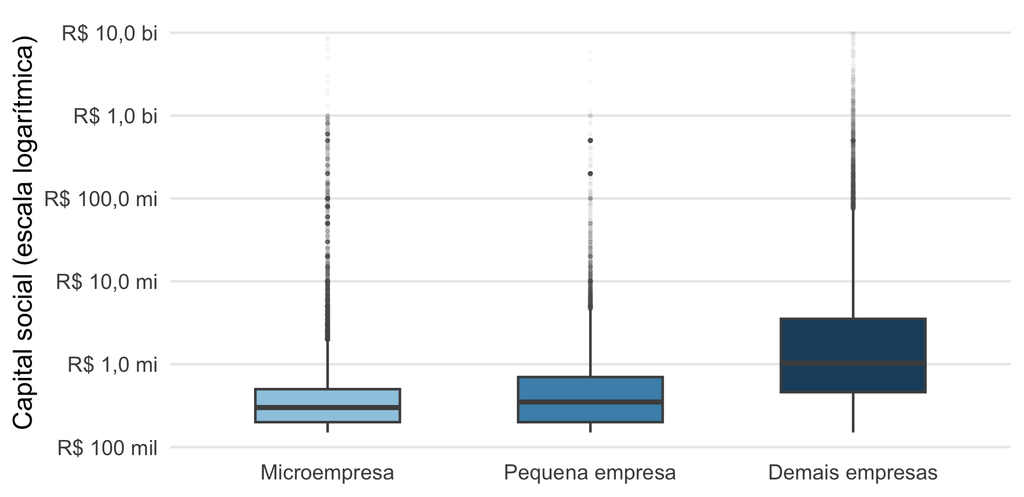

Figura 3.4: Capital social por porte declarado, em escala logarítmica. A sobreposição entre microempresa e pequena empresa é quase total; apenas a categoria residual se distingue.

A sobreposição visível entre as duas primeiras categorias admite explicação direta, e ela não é defeito do cadastro. Porte e capital social medem coisas diferentes: o enquadramento como microempresa ou empresa de pequeno porte depende da receita bruta anual auferida, enquanto o capital social é o comprometimento declarado pelos sócios na constituição da sociedade. Nada na legislação vincula um ao outro, e o resultado aqui obtido é a constatação empírica dessa independência parcial. Uma empresa pode ser constituída com capital de dois milhões e faturar pouco o suficiente para se enquadrar como microempresa; o caminho inverso também é admitido.

Chama atenção, na última coluna da Tabela 3.4, que o índice de Gini interno seja elevado nos três grupos, situando-se acima de 0,92 em todos eles. A desigualdade de capital não se explica pela composição de portes: ela existe dentro de cada porte, com intensidade comparável à do conjunto.

## 3.4 Forma jurídica

Tabela 3.5: As seis formas jurídicas mais frequentes, ordenadas por número de empresas. As colunas de capital total mostram o peso de cada forma na soma declarada.

| Forma jurídica | Empresas | % | Mediana | Capital total | % do capital |
| --- | --- | --- | --- | --- | --- |
| Limited Liability Business Company (LLC) | 119.033 | 84,4 | R$ 400.000 | R$ 724,8 bi | 56,6 |
| Sole Proprietorship | 15.209 | 10,8 | R$ 300.000 | R$ 179,2 bi | 14,0 |
| Privately Held Corporation | 2.893 | 2,1 | R$ 4.495.243 | R$ 286,4 bi | 22,4 |
| Silent Partnership | 2.584 | 1,8 | R$ 1.350.000 | R$ 17,2 bi | 1,3 |
| Simple Limited Partnership | 550 | 0,4 | R$ 500.000 | R$ 2,1 bi | 0,2 |
| Individual Limited Liability Company… | 182 | 0,1 | R$ 300.000 | R$ 1,5 bi | 0,1 |

```r
i_ltda <- grep("^Limited", principais)[1]
i_sa   <- grep("^Privately", principais)[1]
nome_ltda <- principais[i_ltda]; nome_sa <- principais[i_sa]
n_ltda <- sum(nat == nome_ltda); n_sa <- sum(nat == nome_sa)
p_ltda_n <- 100 * n_ltda / length(capital); p_sa_n <- 100 * n_sa / length(capital)
p_sa_cap <- 100 * sum(capital[nat == nome_sa]) / sum(capital)
p_ltda_cap <- 100 * sum(capital[nat == nome_ltda]) / sum(capital)
razao_med <- median(capital[nat == nome_sa]) / median(capital[nat == nome_ltda])
```

A Tabela 3.5 reúne as seis formas jurídicas mais frequentes e evidencia um desencontro entre contagem e valor. A sociedade limitada responde por 84,4 por cento dos cadastros e por 56,6 por cento do capital declarado. A companhia fechada, com apenas 2,1 por cento dos cadastros, concentra 22,4 por cento do capital. A mediana de capital de uma companhia fechada é 11,2 vezes a de uma sociedade limitada.

A Figura 3.5 traduz esse contraste graficamente.

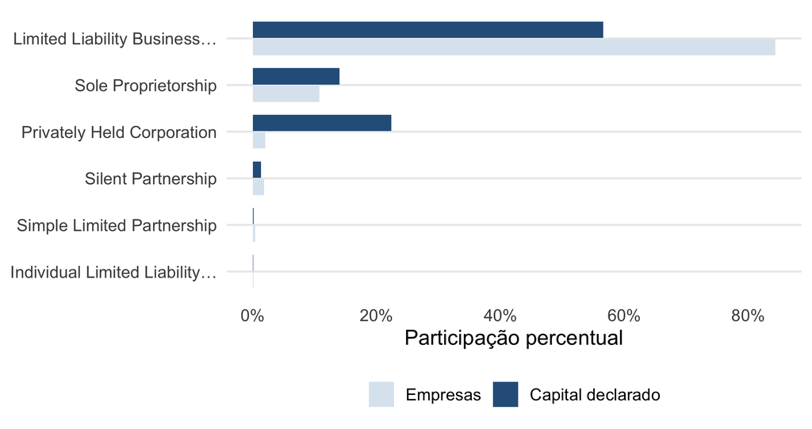

Figura 3.5: Participação de cada forma jurídica no número de empresas e no capital social total declarado. A inversão entre as duas barras é o resultado central desta seção.

```r
porte_cat <- droplevels(porte)
nat_cat <- ifelse(nat %in% principais, encurtar(nat, 30), "Outras formas")
tabela_cont <- table(nat_cat, porte_cat)
qui <- suppressWarnings(chisq.test(tabela_cont))
v_cramer <- sqrt(unname(qui$statistic) /
                 (sum(tabela_cont) * (min(dim(tabela_cont)) - 1)))
```

A tentação, diante desses números, é concluir que a forma jurídica determina a escala de capital, e a conclusão seria precipitada. Forma jurídica e porte não são independentes: o teste de qui-quadrado aplicado à tabela de contingência entre as duas variáveis fornece $\chi^2 = 27.254$ com 12 graus de liberdade e V de Cramér igual a 0,311, associação de intensidade moderada. Companhias fechadas tendem a ser empresas que não se enquadram como micro ou pequenas, e parte da diferença de capital atribuída à forma jurídica é, portanto, diferença de porte.

A Figura 3.6 mostra como se distribui o porte dentro de cada forma jurídica, o que torna essa associação visível.

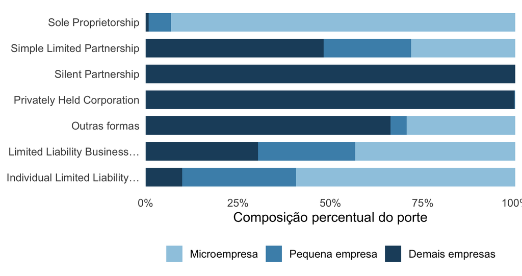

Figura 3.6: Composição de porte dentro de cada forma jurídica. As barras somam 100% em cada linha, de modo que o que se compara é a proporção e não o número absoluto de empresas.

A leitura da figura confirma o que o coeficiente anuncia. A sociedade limitada apresenta composição de porte próxima à da base como um todo, enquanto a companhia fechada é majoritariamente formada por empresas da categoria residual. A diferença de capital entre as duas formas, medida na Tabela 3.5, mistura dois efeitos que os dados disponíveis não permitem separar, porque a separação exigiria controlar o porte, e o porte aqui tem apenas três níveis dos quais um é definido por negação. Registrar essa impossibilidade é mais honesto do que apresentar uma estimativa condicional que a estrutura dos dados não sustenta.

## 3.5 Qualificação do responsável

A terceira variável categórica informa a qualificação do responsável legal registrado no cadastro. Trata-se de informação de natureza societária, e não econômica, mas que se revelou discriminante.

Tabela 3.6: As seis qualificações de responsável mais frequentes, com a distribuição de capital social associada a cada uma.

| Qualificação | Empresas | % | Mediana | 3º quartil | % do capital |
| --- | --- | --- | --- | --- | --- |
| Managing Partner / Partner-Administrator | 106.773 | 75,7 | R$ 350.000 | R$ 800.000 | 35,7 |
| Administrator / Manager | 15.234 | 10,8 | R$ 1.250.000 | R$ 4.687.539 | 22,1 |
| Entrepreneur / Business Owner | 15.201 | 10,8 | R$ 300.000 | R$ 600.000 | 14,0 |
| Director / Officer | 1.630 | 1,2 | R$ 6.913.312 | R$ 44.950.000 | 18,8 |
| President / Chair | 1.342 | 1,0 | R$ 2.467.922 | R$ 12.911.520 | 7,0 |
| Beneficial Owner (individual) resident… | 441 | 0,3 | R$ 300.000 | R$ 500.000 | 1,6 |

```r
q6 <- qual %in% prin_q
kw_q <- kruskal.test(capital[q6] ~ factor(qual[q6]))
kq <- length(prin_q)
eps2_q <- (unname(kw_q$statistic) - kq + 1) / (sum(q6) - kq)
i_soc <- grep("^Managing", prin_q)[1]
i_pre <- grep("^President", prin_q)[1]
med_soc <- median(capital[qual == prin_q[i_soc]])
med_pre <- median(capital[qual == prin_q[i_pre]])
```

A Tabela 3.6 mostra uma concentração extrema em uma única categoria: 75,7 por cento dos cadastros registram como responsável um sócio-administrador. A distribuição das demais categorias é longa e rarefeita, com qualificações como liquidante, inventariante e administrador judicial aparecendo em algumas dezenas de cadastros cada.

Apesar desse desequilíbrio, as medianas de capital diferem de modo apreciável entre as categorias principais. Cadastros cujo responsável é registrado como presidente apresentam mediana de R$ 2.467.922, contra R$ 350.000 nos cadastros de sócio-administrador, razão de 7,1 entre as duas. O teste de Kruskal-Wallis restrito às seis categorias principais fornece $H = 14.278,8$ com tamanho de efeito $\varepsilon^2 = 0,102$.

Esse tamanho de efeito merece comentário, porque ilustra o ponto metodológico da Seção 2.5.2 em sentido oposto ao do porte. O valor-p aqui também é desprezível, e também desprovido de informação. O $\varepsilon^2$, porém, situa-se no patamar de efeito médio, bem abaixo do observado para o porte. A qualificação do responsável distingue grupos, mas explica pouco da variabilidade do capital, e a diferença entre as medianas, embora real, convive com dispersão interna que a supera largamente. Relatar apenas a razão entre medianas, sem essa qualificação, daria à variável uma importância que ela não tem.

A interpretação substantiva é plausível e vale como hipótese, não como conclusão: a designação de um presidente ou diretor como responsável é típica de estruturas societárias mais formalizadas, que tendem a corresponder a empresas de maior capital. A variável funciona, nessa leitura, como indicador indireto de complexidade societária.

## 3.6 A cauda superior

As seções anteriores descreveram o corpo da distribuição. A cauda superior exige tratamento próprio, porque é nela que reside a maior parte do capital declarado e porque o seu comportamento determina se estatísticas baseadas em somas podem ser usadas.

Tabela 3.7: Participação de diferentes faixas da distribuição no capital social total declarado.

| Grupo | Empresas | Corte de capital | % do capital declarado |
| --- | --- | --- | --- |
| Metade inferior | 72.841 | até R$ 400.000 | 1,43 |
| Decil superior (10%) | 14.110 | a partir de R$ 3,8 mi | 93,86 |
| Centésimo superior (1%) | 1.411 | a partir de R$ 156,7 mi | 73,68 |
| Milésimo superior (0,1%) | 142 | a partir de R$ 1,0 bi | 31,28 |
| As 10 maiores | 10 | a partir de R$ 7,6 bi | 6,95 |

Os números da Tabela 3.7 dispensam ênfase retórica. A metade inferior das empresas, 72.841 cadastros, detém 1,43 por cento do capital declarado. O centésimo superior detém 73,7 por cento. As dez maiores empresas do recorte reúnem 7,0 por cento do total.

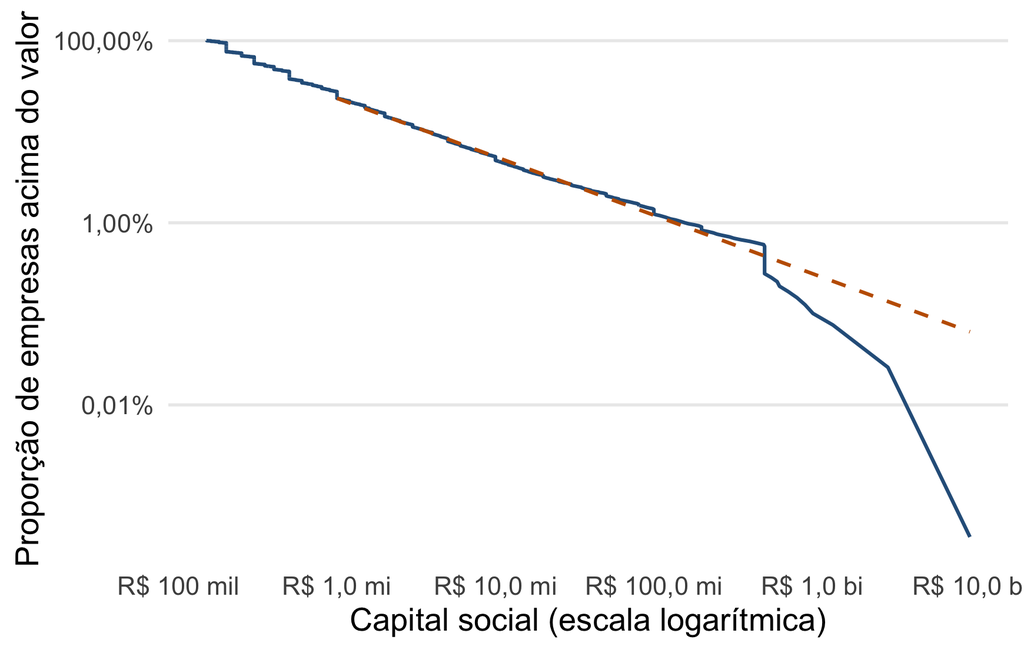

Figura 3.7: Função de sobrevivência empírica do capital social em escala duplamente logarítmica. O trecho aproximadamente retilíneo acima de R$ 1 milhão é a assinatura de uma lei de potência; a reta tracejada corresponde ao expoente estimado pelo método de Hill.

```r
x_ord <- sort(capital)
surv <- 1 - (seq_along(x_ord) - 0.5) / length(x_ord)
amos <- seq(1, length(x_ord), length.out = 4000)

u1 <- 1e6
cauda1 <- capital[capital > u1]
alpha1 <- 1 / mean(log(cauda1 / u1))
u2 <- 1e7
cauda2 <- capital[capital > u2]
alpha2 <- 1 / mean(log(cauda2 / u2))

prop_u1 <- mean(capital > u1)
ref <- data.frame(lx = log10(c(u1, max(capital))))
ref$ly <- log10(prop_u1) - alpha1 * (ref$lx - log10(u1))

ggplot(data.frame(lx = log10(x_ord[amos]), ly = log10(surv[amos])),
       aes(lx, ly)) +
  geom_line(colour = CORES$principal, linewidth = 0.7) +
  geom_line(data = ref, aes(lx, ly), colour = CORES$destaque,
            linetype = "dashed", linewidth = 0.7) +
  scale_x_continuous(labels = rotulo_log10, n.breaks = 6) +
  scale_y_continuous(labels = function(v) paste0(numero_pt(100 * 10^v, 2), "%")) +
  labs(x = "Capital social (escala logarítmica)",
       y = "Proporção de empresas acima do valor") +
  tema_app()
```

A Figura 3.7 mostra a função de sobrevivência empírica em escala duplamente logarítmica. Acima de um milhão de reais o traçado se aproxima de uma reta, forma característica de uma lei de potência, em que a proporção de observações acima de um valor decresce como potência desse valor (NEWMAN, 2005). O estimador de Hill fornece $\hat{\alpha} = 0,642$ para o limiar de um milhão de reais, com 32.870 observações acima do corte, e $\hat{\alpha} = 0,617$ para o limiar de dez milhões, com 6.856 observações. A proximidade entre as duas estimativas indica estabilidade razoável.

A consequência teórica desse resultado é a parte que importa. Em uma distribuição de Pareto com expoente $\alpha$, o momento de ordem $k$ existe somente se $\alpha > k$. Com $\hat{\alpha}$ abaixo de um, nem a média populacional existe, o que significa que a média amostral não converge para nenhum valor à medida que a amostra cresce: ela apenas acompanha a maior observação já encontrada. Isso explica, de forma mais fundamental do que a simples constatação de assimetria, por que a média de R$ 9.084.049 apresentada na Tabela 3.1 não deve ser usada como resumo, e fornece o fundamento formal da preferência pela mediana adotada ao longo de todo o relatório. Acrescente-se a ressalva devida: o estimador de Hill supõe cauda regularmente variável, e a presença de valores ancorados discutida na Seção 3.2 afeta a amostra também nessa região, de modo que o expoente deve ser lido como ordem de magnitude e não como estimativa de precisão.

## 3.7 Concentração

```r
g_obs <- gini(capital)

B <- 1000
g_boot <- replicate(B, gini(sample(capital, replace = TRUE)))
ic <- quantile(g_boot, c(.025, .975))

g_total <- gini(empresas$capital_stock)
```

O índice de Gini do capital social declarado é 0,9429, com intervalo de confiança de 95 por cento obtido por reamostragem de 0,9388 a 0,9463. A estreiteza do intervalo, de pouco mais de 7 milésimos, decorre do tamanho da amostra e indica que a concentração medida não é artefato de variabilidade amostral.

A magnitude do índice pede contextualização para ser compreendida. Índices de Gini de renda domiciliar situam-se tipicamente entre 0,25 e 0,60, sendo o Brasil um dos países de maior desigualdade de renda do mundo com valores em torno de 0,52. Um Gini de 0,943 descreve concentração de outra ordem, próxima do máximo teórico de um, que corresponderia a uma única empresa detendo todo o capital. A comparação, porém, precisa ser feita com cuidado: distribuições de riqueza e de tamanho de firma são sistematicamente mais concentradas do que distribuições de renda, e não há razão para esperar valores comparáveis.

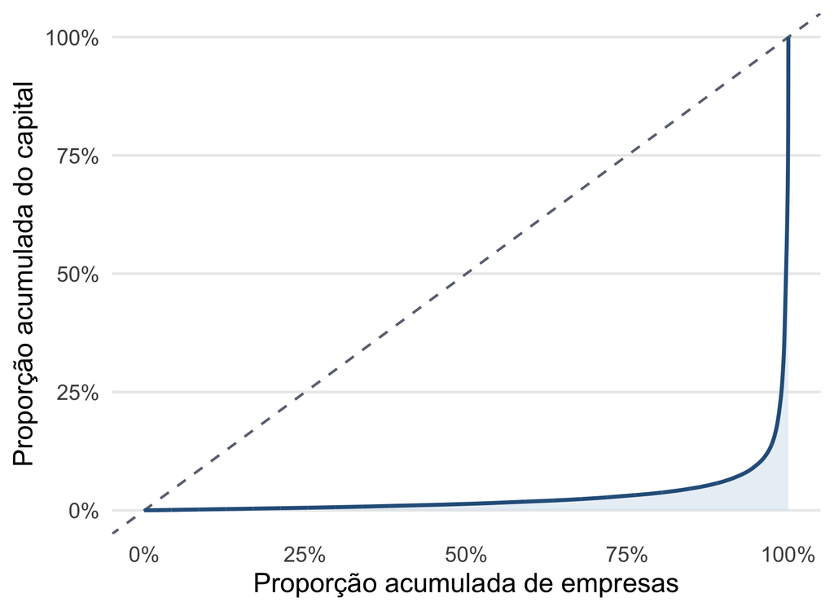

Figura 3.8: Curva de Lorenz do capital social declarado. A diagonal representa a igualdade perfeita. A área entre as duas linhas, normalizada, é o índice de Gini.

```r
x_s <- sort(capital)
p_emp <- seq_along(x_s) / length(x_s)
p_cap <- cumsum(x_s) / sum(x_s)
idx <- unique(round(seq(1, length(x_s), length.out = 3000)))

ggplot(data.frame(p_emp = p_emp[idx], p_cap = p_cap[idx]),
       aes(p_emp, p_cap)) +
  geom_abline(slope = 1, intercept = 0, colour = CORES$neutro,
              linetype = "dashed") +
  geom_area(fill = CORES$claro, alpha = 0.6) +
  geom_line(colour = CORES$principal, linewidth = 0.9) +
  scale_x_continuous(labels = function(v) paste0(numero_pt(100 * v), "%")) +
  scale_y_continuous(labels = function(v) paste0(numero_pt(100 * v), "%")) +
  labs(x = "Proporção acumulada de empresas",
       y = "Proporção acumulada do capital") +
  tema_app()
```

A Figura 3.8 mostra a curva de Lorenz correspondente. O seu traçado permanece rente ao eixo horizontal ao longo de quase toda a extensão e sobe de forma abrupta apenas na última fração, comportamento consistente com o expoente estimado na Seção 3.6.

Dois esclarecimentos devem acompanhar esse resultado. O primeiro é o truncamento, já mencionado: como a base exclui as empresas de capital inferior a cento e cinquenta mil reais, que são a maioria numérica no CNPJ, o índice aqui calculado mede a desigualdade interna de um grupo já selecionado pelo alto. A desigualdade do universo empresarial brasileiro é necessariamente superior, e este valor é um limite inferior. O segundo é a ausência de identificação de grupo econômico. Cadastros de um mesmo conglomerado contam como empresas distintas, de modo que a concentração de propriedade também é subestimada.

Cabe registrar, ainda, que o índice calculado sobre a base completa, incluindo os valores implausíveis, é de 0,9976. A diferença em relação ao valor do recorte é pequena em termos absolutos, e esse é um ponto sutil que vale explicitar: o Gini é relativamente robusto à inclusão desses registros porque já estava próximo do seu máximo, enquanto a média, como se verá, não é. Robustez de um índice não implica robustez de todos.

## 3.8 A qualidade do registro

Os valores implausíveis mencionados ao longo do relatório são descritos e quantificados nesta seção.

Tabela 3.8: Os seis valores mais frequentes entre os 262 cadastros com capital declarado igual ou superior a R$ 10 bilhões.

| Valor declarado | Empresas |
| --- | --- |
| R$ 100,0 bi | 184 |
| R$ 20,0 bi | 26 |
| R$ 1000,0 bi | 23 |
| R$ 18,0 bi | 5 |
| R$ 999,0 bi | 2 |
| R$ 1000,0 bi | 2 |

A repetição é o argumento decisivo. Empresas diferentes, com razões sociais sem relação aparente, declarando exatamente cem bilhões de reais não constituem coincidência econômica. O padrão é o de um valor usado como preenchimento, seja por erro de digitação, seja por campo preenchido com máximo admitido, seja por registro de teste que permaneceu na base.

```r
cap_total_com <- sum(empresas$capital_stock)
cap_total_sem <- sum(capital)
contrib <- 100 * (cap_total_com - cap_total_sem) / cap_total_com

efeito <- data.frame(
  Estatística = c("Número de empresas", "Capital total declarado",
                  "Média", "Mediana", "Desvio padrão", "Máximo",
                  "Índice de Gini"),
  `Base completa` = c(numero_pt(n_total), reais_curto(cap_total_com),
                      reais(mean(empresas$capital_stock)),
                      reais(median(empresas$capital_stock)),
                      reais_curto(sd(empresas$capital_stock)),
                      reais_curto(max(empresas$capital_stock)),
                      numero_pt(g_total, 4)),
  `Recorte de análise` = c(numero_pt(n_validas), reais_curto(cap_total_sem),
                           reais(media), reais(mediana), reais_curto(dp),
                           reais_curto(max(capital)), numero_pt(g_obs, 4)),
  check.names = FALSE, stringsAsFactors = FALSE
)
knitr::kable(efeito, align = c("l", "r", "r"), caption = "Efeito dos 262 valores implausíveis sobre as estatísticas da base. A coluna da esquerda inclui todos os cadastros; a da direita, apenas o recorte de análise.")
```

Tabela 3.9: Efeito dos 262 valores implausíveis sobre as estatísticas da base. A coluna da esquerda inclui todos os cadastros; a da direita, apenas o recorte de análise.

| Estatística | Base completa | Recorte de análise |
| --- | --- | --- |
| Número de empresas | 141.332 | 141.070 |
| Capital total declarado | R$ 50,0 tri | R$ 1,3 tri |
| Média | R$ 353.697.048 | R$ 9.084.049 |
| Mediana | R$ 400.000 | R$ 400.000 |
| Desvio padrão | R$ 14,6 bi | R$ 122,9 mi |
| Máximo | R$ 1000,0 bi | R$ 9,9 bi |
| Índice de Gini | 0,9976 | 0,9429 |

A Tabela 3.9 quantifica o efeito desses registros, e o resultado é o achado de maior consequência prática do trabalho. Os 262 cadastros, que representam 0,185 por cento das empresas, respondem por 97,4 por cento do capital social agregado da base. A média calculada com eles é de R$ 353.697.048, contra R$ 9.084.049 no recorte de análise, razão de 38,9 entre as duas.

A diferença entre essas duas médias não é uma questão de refinamento estatístico. Uma análise que tomasse a média da base completa como medida de capital típico reportaria um valor errado por quase duas ordens de magnitude, e o erro seria produzido por menos de dois décimos de um por cento das observações. Já a mediana se altera de R$ 400.000 para R$ 400.000, variação desprezível, o que demonstra na prática a propriedade de resistência que justifica a sua escolha.

É este resultado que justifica a decisão de marcar, e não excluir, os registros implausíveis na importação: excluí-los produziria uma análise mais simples ao custo de tornar invisível o seu efeito.

## 3.9 Síntese dos resultados

Tabela 3.10: Síntese das medidas principais obtidas em cada aspecto analisado.

| Aspecto | Medida principal |
| --- | --- |
| Forma da distribuição | assimetria = 46,0; média/mediana = 22,7 |
| Arredondamento | 60% das declarações são múltiplas de R$ 100 mil |
| Porte declarado | ε² = 0,196 |
| Forma jurídica | V de Cramér = 0,311 |
| Qualificação do responsável | ε² = 0,102 |
| Cauda superior | expoente de Hill = 0,64 |
| Concentração | Gini = 0,943 |
| Qualidade do registro | 0,185 % dos cadastros detêm 97,4 % do capital |

A Tabela 3.10 reúne as medidas centrais de cada seção. Lidas em conjunto, elas sustentam uma leitura unificada: a distribuição do capital social declarado é governada por dois regimes distintos. No corpo, a variável se comporta de maneira compatível com a lognormal e é fortemente moldada pelo comportamento declaratório, com arredondamento maciço e ancoragem em poucas quantias de referência. Na cauda, ela segue uma lei de potência de expoente tão baixo que a média populacional não existe, e nela se concentra quase todo o capital agregado. A qualidade do registro atua sobre os dois regimes, mas é na cauda que ela se torna determinante, porque é lá que uma única declaração indevida desloca a soma.

# 4 Conclusão

Este trabalho analisou o capital social declarado por 141.332 empresas brasileiras registradas no CNPJ, com o objetivo de caracterizar a sua distribuição e de separar, na medida do possível, o que nela é propriedade da economia do que é propriedade do processo de declaração.

A distribuição mostrou-se fortemente assimétrica à direita, com coeficiente de assimetria de 46,0 e média 22,7 vezes superior à mediana. A transformação logarítmica produz forma aproximadamente normal no corpo da distribuição, mas falha nas duas extremidades, à esquerda pelo truncamento da amostra e à direita pela cauda pesada. O exame da cauda por meio do estimador de Hill forneceu expoente de 0,64, inferior a um, resultado que implica inexistência da média populacional e que fundamenta formalmente a preferência pela mediana mantida em todo o relatório.

A concentração do capital declarado é extrema, com índice de Gini de 0,943 e intervalo de confiança por reamostragem de 0,939 a 0,946. A metade inferior das empresas detém 1,4 por cento do capital, enquanto o centésimo superior detém 73,7 por cento. Esse resultado é um limite inferior em dois sentidos, pelo truncamento da amostra e pela ausência de identificação de grupos econômicos.

O achado de maior consequência prática, no entanto, é o de qualidade do registro. Os 262 cadastros com capital declarado igual ou superior a dez bilhões de reais, que representam 0,185 por cento das observações, respondem por 97,4 por cento do capital agregado e multiplicam a média por 38,9. Somem-se a esses o arredondamento maciço, com 60 por cento das declarações inteiras múltiplas de cem mil reais, e a ancoragem em poucas quantias de referência, com os dez valores mais comuns cobrindo 56,3 por cento da base. O campo de capital social não registra, portanto, uma medida econômica: registra uma decisão declaratória, feita em grande parte por escolha de um número redondo, e eventualmente preenchida com valores que nenhuma empresa poderia ter.

Esse diagnóstico tem consequência metodológica que extrapola o conjunto analisado. Nenhuma das distorções encontradas se manifestaria em uma verificação de consistência convencional. Não há valores ausentes, não há tipos incorretos, não há violação de domínio: todos os 141.332 registros passariam por qualquer validação de esquema. A distorção só aparece quando se examina a distribuição, e aparece como um pico onde não deveria haver pico ou como uma média que não corresponde a nenhuma observação. Esse é o argumento prático a favor de iniciar a análise de um conjunto desconhecido pela sua distribuição, e não pelo seu resumo.

Como desdobramentos, três linhas se apresentam. A primeira é o cruzamento com as bases de estabelecimentos e de sócios do CNPJ, publicadas pela mesma fonte, o que permitiria recuperar a data de abertura, a localização e a atividade econômica, e com isso examinar as dimensões que aqui foram declaradas fora de escopo. A segunda é a modelagem explícita da cauda, com estimação por máxima verossimilhança do limiar e do expoente da lei de potência e comparação formal com alternativas lognormais. A terceira é a construção de um critério de plausibilidade mais fino que o limiar fixo de dez bilhões adotado aqui, possivelmente baseado na combinação entre repetição do valor, grau de arredondamento e forma jurídica declarada.

# 5 Referências

AITCHISON, John; BROWN, J. A. C. **The Lognormal Distribution, with Special Reference to its Uses in Economics**. Cambridge: Cambridge University Press, 1957

BENFORD, Frank. The Law of Anomalous Numbers. **Proceedings of the American Philosophical Society**. v. 78, n. 4, p. 551–572, 1938

BRASIL. **Lei nº 10.406, de 10 de janeiro de 2002: institui o Código Civil**. Diário Oficial da União, 2002. Disponível em: <https://www.planalto.gov.br/ccivil_03/leis/2002/l10406compilada.htm>

BRASIL. **Lei Complementar nº 123, de 14 de dezembro de 2006**. Institui o Estatuto Nacional da Microempresa e da Empresa de Pequeno Porte, 2006. Disponível em: <https://www.planalto.gov.br/ccivil_03/leis/lcp/lcp123.htm>

CHANG, Winston *et al.* **[shiny: Web Application Framework for R](https://shiny.posit.co/)**. [*s. l.*]: Posit Software, 2026

COHEN, Jacob. **Statistical Power Analysis for the Behavioral Sciences**. 2. ed. Hillsdale: Lawrence Erlbaum Associates, 1988

CONOVER, W. J.; IMAN, Ronald L. [Rank Transformations as a Bridge between Parametric and Nonparametric Statistics](https://doi.org/10.1080/00031305.1981.10479327). **The American Statistician**. v. 35, n. 3, p. 124–129, 1981

COWELL, Frank A. **Measuring Inequality**. 3. ed. Oxford: Oxford University Press, 2011

CRAMÉR, Harald. **Mathematical Methods of Statistics**. Princeton: Princeton University Press, 1946

EFRON, Bradley. [Bootstrap Methods: Another Look at the Jackknife](https://doi.org/10.1214/aos/1176344552). **The Annals of Statistics**. v. 7, n. 1, p. 1–26, 1979

GINI, Corrado. [Measurement of Inequality of Incomes](https://doi.org/10.2307/2223319). **The Economic Journal**. v. 31, n. 121, p. 124–126, 1921

HILL, Bruce M. [A Simple General Approach to Inference about the Tail of a Distribution](https://doi.org/10.1214/aos/1176343247). **The Annals of Statistics**. v. 3, n. 5, p. 1163–1174, 1975

HUNTINGTON-KLEIN, Nick. Effect Sizes and Statistical Significance in Large Samples. **Journal of Econometric Methods**. v. 6, n. 1, p. 1–10, 2017

KRUSKAL, William H.; WALLIS, W. Allen. [Use of Ranks in One-Criterion Variance Analysis](https://doi.org/10.1080/01621459.1952.10483441). **Journal of the American Statistical Association**. v. 47, n. 260, p. 583–621, 1952

LIMPERT, Eckhard; STAHEL, Werner A.; ABBT, Markus. Log-normal Distributions across the Sciences: Keys and Clues. **BioScience**. v. 51, n. 5, p. 341–352, 2001

LORENZ, M. O. [Methods of Measuring the Concentration of Wealth](https://doi.org/10.2307/2276207). **Publications of the American Statistical Association**. v. 9, n. 70, p. 209–219, 1905

NEWMAN, M. E. J. [Power Laws, Pareto Distributions and Zipf’s Law](https://doi.org/10.1080/00107510500052444). **Contemporary Physics**. v. 46, n. 5, p. 323–351, 2005

NIGRINI, Mark J. **Benford’s Law: Applications for Forensic Accounting, Auditing, and Fraud Detection**. Hoboken: John Wiley & Sons, 2012

PARETO, Vilfredo. **Cours d’Économie Politique**. Lausanne: F. Rouge, 1896. v. 2

R CORE TEAM. **[R: A Language and Environment for Statistical Computing](https://www.R-project.org/)**. Vienna, Austria: R Foundation for Statistical Computing, 2026

R4DS ONLINE LEARNING COMMUNITY. **Brazilian Companies: conjunto de dados da semana de 27 de janeiro de 2026**. Repositório rfordatascience/tidytuesday, GitHub, 2026. Disponível em: <https://github.com/rfordatascience/tidytuesday/tree/main/data/2026/2026-01-27>

RECEITA FEDERAL DO BRASIL. **Cadastro Nacional da Pessoa Jurídica — CNPJ: dados abertos**. Portal Brasileiro de Dados Abertos, 2026. Disponível em: <https://dados.gov.br/dados/conjuntos-dados/cadastro-nacional-da-pessoa-juridica---cnpj>

SEBRAE. **Critérios de classificação de empresas por porte**. Serviço Brasileiro de Apoio às Micro e Pequenas Empresas, 2024

TUKEY, John W. **Exploratory Data Analysis**. Reading, MA: Addison-Wesley, 1977

WICKHAM, Hadley. **[ggplot2: Elegant Graphics for Data Analysis](https://ggplot2.tidyverse.org)**. 2. ed. New York: Springer-Verlag, 2016

XIE, Yihui. **[bookdown: Authoring Books and Technical Documents with R Markdown](https://bookdown.org/yihui/bookdown/)**. Boca Raton: CRC Press, 2016

XIE, Yihui; ALLAIRE, J. J.; GROLEMUND, Garrett. **[R Markdown: The Definitive Guide](https://bookdown.org/yihui/rmarkdown/)**. Boca Raton: CRC Press, 2018

# Apêndice A — Ambiente computacional

Tabela 5.1: Ambiente computacional em que este relatório foi compilado.

| Item | Valor |
| --- | --- |
| Versão do R | R version 4.6.1 (2026-06-24) |
| Sistema | darwin23 |
| Plataforma | aarch64-apple-darwin23 |
| Pacote ggplot2 | 4.0.3 |
| Pacote knitr | 1.52 |
| Pacote rmarkdown | 2.32 |
| Pacote bookdown | 0.48 |
| Pacote shiny | 1.14.0 |
| Pacote DT | 0.34.0 |

O documento é compilado a partir do arquivo `relatorio/relatorio.Rmd`, que lê o conjunto tratado em `dados/tratados/companies.rds` e as funções comuns em `R/comum.R`. A compilação não exige acesso à rede nem execução prévia dos scripts de importação, porque o arquivo tratado está versionado no repositório.

# Apêndice B — O aplicativo interativo

A segunda parte do trabalho consiste em um aplicativo construído com shiny (CHANG et al., 2026), organizado em dez abas, cada uma com um aspecto distinto da mesma base, seus próprios seletores, ao menos um gráfico e ao menos uma tabela. As abas tratam, na ordem: panorama geral, distribuição do capital, porte, forma jurídica, qualificação do responsável, cruzamento de duas categorias, cauda superior, concentração, qualidade do dado e busca de empresas individuais.

A arquitetura adotada merece registro porque resolveu um problema de organização de trabalho. Cada aba é um módulo shiny em arquivo próprio, com uma função de interface e uma função de servidor, e o arquivo principal apenas reúne a lista de abas. Essa separação permite que integrantes diferentes trabalhem simultaneamente sem conflito de versionamento, já que alterações em arquivos distintos não competem pelas mesmas linhas.

As funções de formatação de valores em reais, de rotulagem de eixos logarítmicos e de nomes de categorias são compartilhadas entre o aplicativo e este relatório, por meio do arquivo `R/comum.R`. A consequência é que os dois produtos não podem divergir na apresentação de um mesmo número, o que seria possível se cada um implementasse a sua própria formatação.

# Apêndice C — Declaração de uso de inteligência artificial

Conforme exigido no enunciado do trabalho, registra-se o uso de ferramentas de inteligência artificial. Foi utilizado o assistente Claude, da Anthropic, no apoio à estruturação do código de importação e tratamento dos dados, na construção dos módulos do aplicativo interativo e na revisão da redação deste relatório. As decisões analíticas, a escolha das técnicas estatísticas, a interpretação dos resultados e a redação final são de responsabilidade dos autores. Todos os valores numéricos apresentados foram conferidos contra o arquivo de diagnóstico produzido pelo script `scripts/02_perfil.R`, gerado independentemente do texto.